# Homework 4

Теперь это похоже на нормализованные данные. Посмотрим на результат MDS:

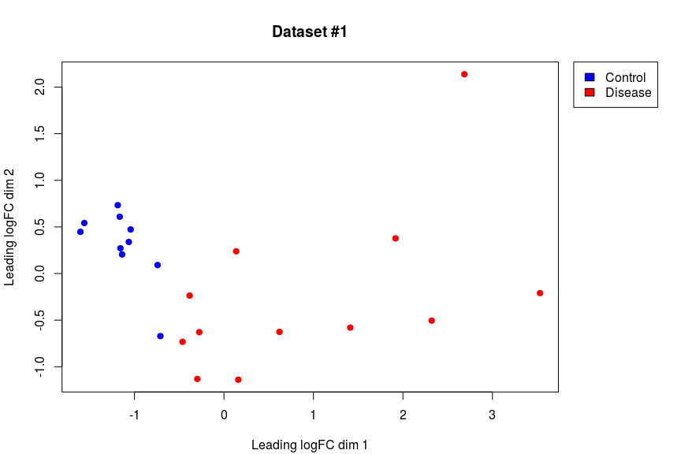

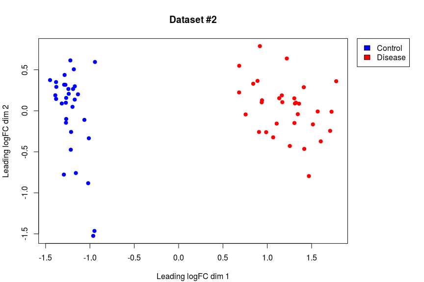

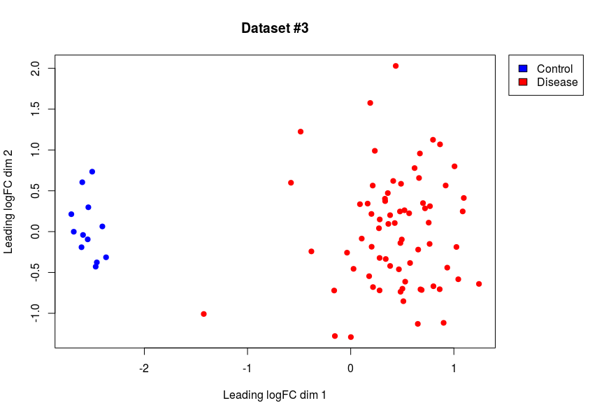

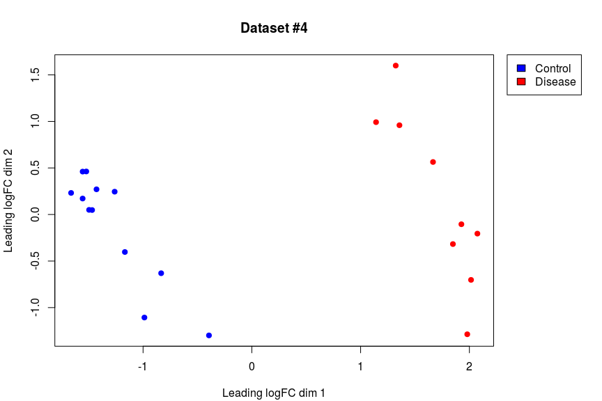

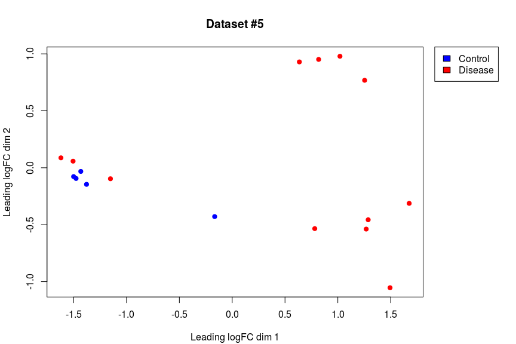

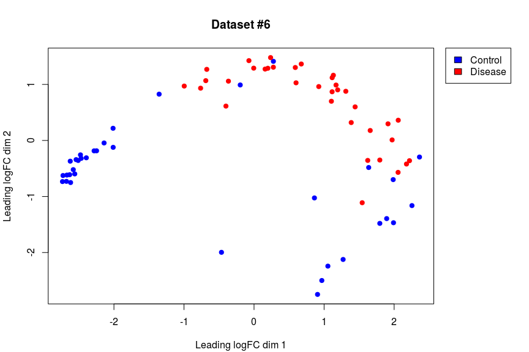

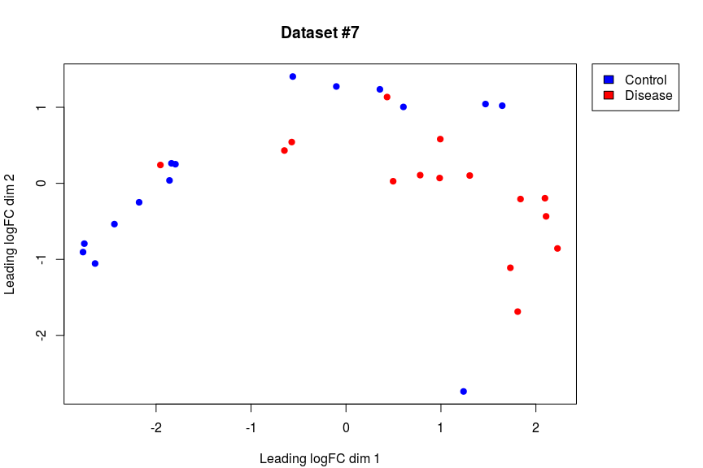

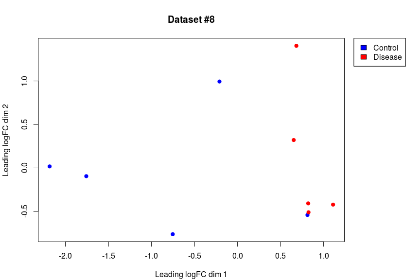

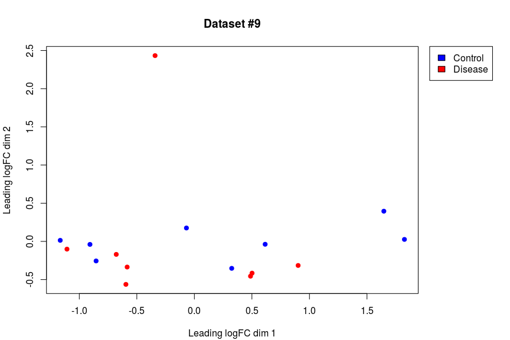

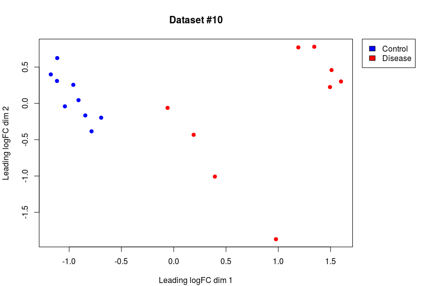

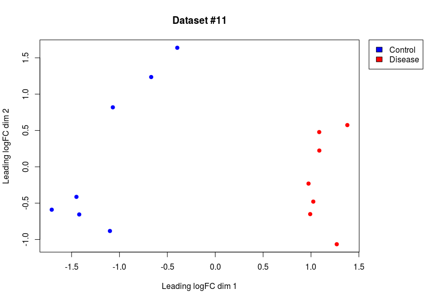

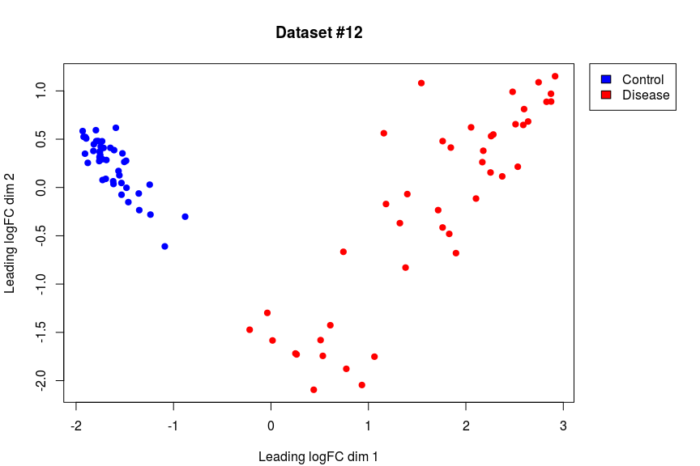

[1 more figures not shown]

```r
par(mar=c(4.1, 4.1, 4.1, 8.1), xpd=TRUE)
lapply(X = norm_data, FUN = function(eset) {
  m <- plotMDS(x = as_tibble(exprs(eset)), pch = 19,
               col = ifelse(pData(eset)$Group == 'c', 'blue', 'red'),
               main = eset@experimentData@title)
  legend('topright', inset = c(-0.2, 0),
         legend = c('Control', 'Disease'), fill = c('blue', 'red'))
})
```

Как видим, местами образцы смешались и четкого разделения между ними нет. Это, возможно, говорит о некачественных данных или перепутанных образцах. Наихудшее разделение - в 5-9 образцах, три из них с платформы hgu133a. С этими образцами и в дальнейшем будут проблемы.

## Дифференциально экспрессирующиеся гены

Воспользуемся пакетом `limma` для поиска дифференциально экспрессирующихся генов при переходе от контрольных образцов к нездоровым. Нам требуются только те гены, экспрессия которых значимо возрастает, поэтому критериями отбора будут значимый q-value (p-value после поправки на множественное тестирование) и logFC > 1.

Кроме того, в процессе подготовки к применению линейной модели возможно будем отфильтровывать низкоэкспрессирующиеся зонды и зонды, которые относятся сразу к нескольким генам.

Напишем несколько вспомогательных функций для работы с каждым из датасетов по отдельности.

```r
intensityHistogram <- function(eset, h = 0) {
  # Строит гистограмму медианных экспрессий зондов для оценки порога фильтрации
  df <- enframe(rowMedians(exprs(eset)), name = NULL)
  ggplot(data = df, mapping = aes(x = value)) +
    geom_histogram(bins = 100, fill = 'grey90', col = 'black') +
    theme_bw() + ylab('Count') + xlab('log(Probe expression)') +
    ggtitle(eset@experimentData@title) +
    scale_x_continuous(breaks = seq.int(from = 0,
                                        to = round(max(df$value)),
                                        by = 1))
}

filterByIntensity <- function(eset, threshold = 0) {
  # Убирает зонды с медианным уровнем экспрессии ниже порога
  v <- rowMedians(exprs(eset))
  t <- table(factor(v > threshold, levels = c(FALSE, TRUE)))
  names(t) <- c('less than threshold', 'greater than threshold')
  # print(t)
  eset <- eset[v > threshold, ]
  return(eset)
}

filteredExpressionObj <- function(eset) {
  # Подготавливает матрицу экспрессии зондов, убирая относящиеся к нескольким генам зонды
  # Возвращает ExObj - list с матрицей экспрессии, списком групп образцов и списком генов
  emat <- as_tibble(x = exprs(eset), rownames = 'PROBEID')
  pdat <- pData(eset)
  platform <- eset@annotation
  anno <- AnnotationDbi::select(x = eval(parse(text = paste0(platform, '.db'))),
                 keys = emat$PROBEID,
                 keytype = 'PROBEID',
                 columns = 'ENTREZID')
  anno <- anno[!is.na(anno$ENTREZID), ]
  multi_probes <- anno %>%
    group_by(PROBEID) %>%
    summarise(no_of_matches = n_distinct(ENTREZID)) %>%
    filter(no_of_matches > 1)
  anno <- anno[!anno$PROBEID %in% multi_probes$PROBEID, ]
  emat <- left_join(anno, emat, by = 'PROBEID')
  return(list(emat = emat[, 3:ncol(emat)],
              ph = as.factor(pdat$Group),
              genes = emat[, 1:2]))
}

linearFitting <- function(ExObj) {
  # Применяет линейную модель (lmFit из limma) к данным
  # Добавляет в ExObj саму модель
  design <- model.matrix(~ 0 + ExObj$ph)
  colnames(design) <- c('Control', 'Disease')
  fit <- lmFit(object = ExObj$emat, design = design)
  ctst <- makeContrasts(Disease-Control, levels = design)
  fit <- contrasts.fit(fit = fit, contrasts = ctst)
  fit <- eBayes(fit = fit)
  ExObj$fit <- fit
  return(ExObj)
}

eset2Fit <- function(eset, threshold = 0) {
  return(
    linearFitting(
      filteredExpressionObj(
        filterByIntensity(eset = eset, threshold = threshold)
        )
      )
    )
}

estimateDE <- function(ExObj, FDR = 0.05, lfc = 1) {
  # Оценивает число upregulated и downregulated генов при заданном уровне значимости
  de <- decideTests(object = ExObj$fit, methold = 'global', adjust.method = 'BH',
                    p.value = FDR, lfc = lfc)
  t <- table(factor(de, levels = c(-1, 0, 1)))
  names(t) <- c('downregulated', 'nonregulated', 'upregulated')
  return(t)
}

rankedGeneList <- function(ExObj, FDR = 0.05, lfc = 1) {
  # Ранжированные по logFC списки upregulated, downregulated и всех генов
  # ENTREZ ID в именах векторов
  tt <- topTable(fit = ExObj$fit, number = Inf, genelist = ExObj$genes$ENTREZID,
                 adjust.method = 'BH', sort.by = 'none')
  ups <- tt %>%
    filter(logFC > lfc, adj.P.Val < FDR) %>%
    dplyr::select(ID, logFC) %>%
    group_by(ID) %>% # так как один ген может получать вклад от нескольких зондов
    summarise(logFC = max(logFC)) %>% # выберем максимальный
    arrange(desc(logFC)) %>%
    deframe()
  downs <- tt %>%
    filter(logFC < lfc, adj.P.Val < FDR) %>%
    dplyr::select(ID, logFC) %>%
    group_by(ID) %>%
    summarise(logFC = min(logFC)) %>%
    arrange(logFC) %>%
    deframe()
  all_genes <- tt %>%
    dplyr::select(ID, logFC) %>%
    group_by(ID) %>%
    summarise(logFC = dplyr::first(logFC)) %>%
    arrange(desc(logFC)) %>%
    deframe()
  return(list(ups = ups, downs = downs, universe = all_genes))
}
```

Функции ниже используются именно для анализа пасвеев. Стоит заметить, что KEGG-пасвеи часто пересекаются, поэтому процедуры поправок на множественное тестирование могут быть слишком консервативны. Помимо q-value стоит обращать внимание и на то, как ведут себя p-value.

```r
oraKEGG <- function(ExObj, FDR = 0.05, lfc = 1) {
  # Эта функция производит ORA-анализ KEGG-пасвеев
  # Возвращает целевые пасвеи, отсортированные по q-value
  kk <- kegga(de = ExObj$fit, species.KEGG = 'hsa',
              geneid = ExObj$genes$ENTREZID, FDR = FDR, lfc = lfc)
  kk$Q.Up <- p.adjust(kk$P.Up, 'BH')
  kk$Q.Down <- p.adjust(kk$P.Down, 'BH')
  kk <- kk[grepl('cancer', kk$Pathway) | grepl('carcinoma', kk$Pathway), ]
  kk <- as_tibble(x = kk, rownames = 'KEGG ID', .name_repair = 'minimal')
  return(head(kk[order(kk$Q.Up), c(1, 2, 6:9)], 10))
}

library(clusterProfiler.dplyr)

ora2KEGG <- function(ExObj, FDR = 0.05, lfc = 1) {
  # Аналог ORA-анализа выше, но из другого пакета
  rgl <- rankedGeneList(ExObj = ExObj, FDR = FDR, lfc = lfc)
  ok <- enrichKEGG(gene = names(rgl$ups),
                   pvalueCutoff = 0.5,
                   universe = names(rgl$universe),
                   minGSSize = 10,
                   maxGSSize = 200)
  ok <- ok %>% filter(grepl('cancer', Description) | grepl('carcinoma', Description))
  return(head(ok@result[, c(1, 2, 5, 7)], 10))
}

gseaKEGG <- function(ExObj) {
  # GSEA-анализ
  rgl <- rankedGeneList(ExObj) # вектор logFC всех генов на вход
  gk <- gseKEGG(geneList = rgl$universe,
                organism = 'hsa',
                nPerm = 10000,
                minGSSize = 10,
                maxGSSize = 200,
                pvalueCutoff = 0.5)
  gk <- gk %>% filter(grepl('cancer', Description) | grepl('carcinoma', Description))
  return(head(gk@result[, c(1, 2, 6, 8)], 10))
}
```

### Dataset 1

Поработаем с первым датасетом. Для начала посмотрим на распределение экспрессии зондов:

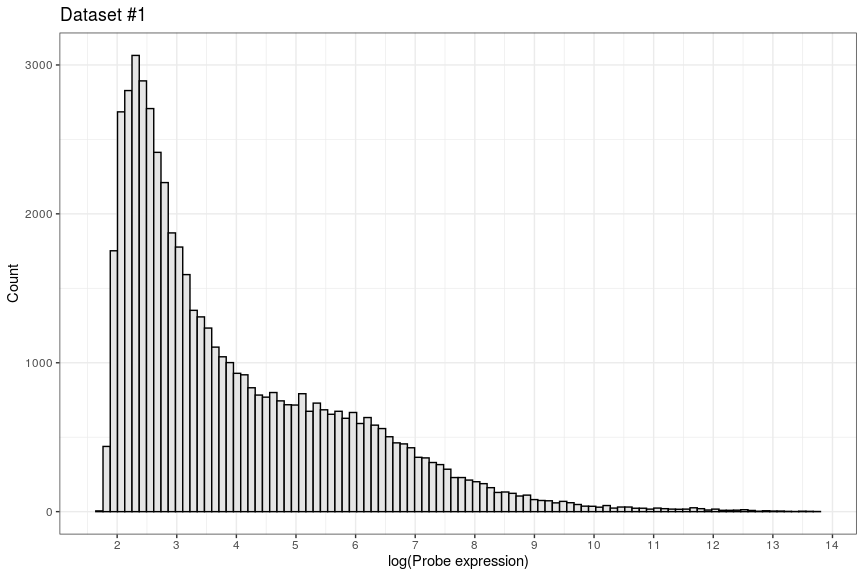

```r
intensityHistogram(eset = norm_data$`Dataset #1`)
```

Изначально была мысль фильтровать датасеты от зондов со слабой экспрессиией, но на самом деле это только ухудшает результаты.

Применим линейную модель для поиска DE-генов:

```r
x1 <- eset2Fit(eset = norm_data$`Dataset #1`)
```

```r
estimateDE(x1)
```

```
downregulated  nonregulated   upregulated
          739         40558           801
```

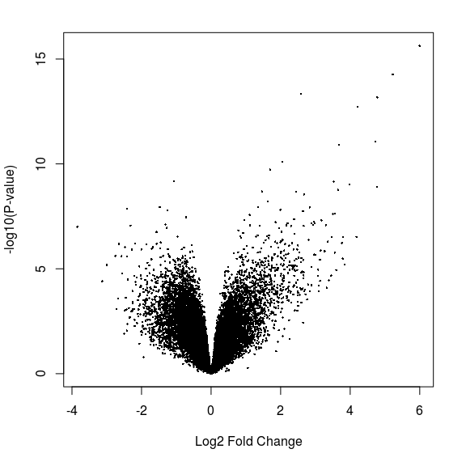

```r
volcanoplot(x1$fit)
```

Видим достаточное количество как upregulated, так и downregulated генов. Volcano-plot также неплохой, обилие точек в правом верхнем углу. Теперь посмотрим что покажет ORA в KEGG-пасвеях:

```r
oraKEGG(x1)
```

| KEGG ID | Pathway | P.Up | P.Down | Q.Up | Q.Down |
| --- | --- | --- | --- | --- | --- |
| path:hsa05205 | Proteoglycans in cancer | 8.796469e-09 | 0.1648627 | 1.477807e-06 | 0.4533200 |
| path:hsa05200 | Pathways in cancer | 8.698762e-06 | 0.1098231 | 4.175406e-04 | 0.3476011 |
| path:hsa05206 | MicroRNAs in cancer | 1.398502e-04 | 0.4316929 | 2.983175e-03 | 0.7973635 |
| path:hsa05202 | Transcriptional misregulation in cancer | 1.520694e-04 | 0.7221742 | 3.005607e-03 | 1.0000000 |
| path:hsa05224 | Breast cancer | 6.903656e-04 | 0.9774219 | 8.591216e-03 | 1.0000000 |
| path:hsa05235 | PD-L1 expression and PD-1 checkpoint pathway in cancer | 1.094423e-02 | 0.7620865 | 6.232645e-02 | 1.0000000 |
| path:hsa05222 | Small cell lung cancer | 1.915637e-02 | 0.3036366 | 9.195056e-02 | 0.6679407 |
| path:hsa05225 | Hepatocellular carcinoma | 2.126072e-02 | 0.4004836 | 9.921669e-02 | 0.7812237 |
| path:hsa05215 | Prostate cancer | 2.900062e-02 | 0.7586801 | 1.188318e-01 | 1.0000000 |
| path:hsa05217 | Basal cell carcinoma | 5.803737e-02 | 0.9857182 | 2.010367e-01 | 1.0000000 |

- P.Up, P.Down - p-value для upregulated и downregulated генов
- Q.Up и Q.Down - соответствующие p-value после поправки на множественное тестирование

Наиболее значимым из подходящих пасвеев оказался hsa05224:Breast Cancer. Посмотрим, что покажет другая реализация ORA-метода (учитывает только upregulated гены):

```r
ora2KEGG(x1)
```

|  | ID | Description | pvalue | qvalue |
| --- | --- | --- | --- | --- |
| 1 | hsa05205 | Proteoglycans in cancer | 2.719102e-07 | 1.822275e-05 |
| 2 | hsa05206 | MicroRNAs in cancer | 1.815598e-02 | 1.351966e-01 |
| 3 | hsa05222 | Small cell lung cancer | 2.215900e-02 | 1.536250e-01 |
| 4 | hsa05202 | Transcriptional misregulation in cancer | 5.574286e-02 | 2.668393e-01 |
| 5 | hsa05224 | Breast cancer | 1.710567e-01 | 5.106345e-01 |
| 6 | hsa05235 | PD-L1 expression and PD-1 checkpoint pathway in cancer | 2.229917e-01 | 5.698832e-01 |
| 7 | hsa05217 | Basal cell carcinoma | 3.950572e-01 | 7.539749e-01 |
| 8 | hsa05219 | Bladder cancer | 4.609794e-01 | 7.679438e-01 |
| 9 | hsa05231 | Choline metabolism in cancer | 4.835435e-01 | 7.679438e-01 |
| 10 | hsa05215 | Prostate cancer | 4.999042e-01 | 7.789566e-01 |

Результат не в согласии с предыдущим, при этом значимость куда ниже. Сделаем также GSEA-анализ:

```r
gseaKEGG(x1)
```

|  | ID | Description | pvalue | qvalues |
| --- | --- | --- | --- | --- |
| 1 | hsa05205 | Proteoglycans in cancer | 0.001195314 | 0.003926532 |
| 2 | hsa05235 | PD-L1 expression and PD-1 checkpoint pathway in cancer | 0.005390836 | 0.012374651 |
| 3 | hsa05224 | Breast cancer | 0.025493799 | 0.044156723 |
| 4 | hsa05202 | Transcriptional misregulation in cancer | 0.050650558 | 0.076589398 |
| 5 | hsa05210 | Colorectal cancer | 0.100894855 | 0.124620133 |
| 6 | hsa05226 | Gastric cancer | 0.107844873 | 0.128500519 |
| 7 | hsa05216 | Thyroid cancer | 0.137139710 | 0.156717182 |
| 8 | hsa05206 | MicroRNAs in cancer | 0.163412366 | 0.178933081 |
| 9 | hsa05231 | Choline metabolism in cancer | 0.199090909 | 0.207279002 |
| 10 | hsa05222 | Small cell lung cancer | 0.231785064 | 0.226467458 |

Результат такой же, как у первого метода. Вывод - **hsa05224:Breast cancer**.

### Dataset 2

Линейная модель:

```r
x2 <- eset2Fit(eset = norm_data$`Dataset #2`)
```

```r
estimateDE(x2)
```

```
downregulated  nonregulated   upregulated
         1146         40110           842
```

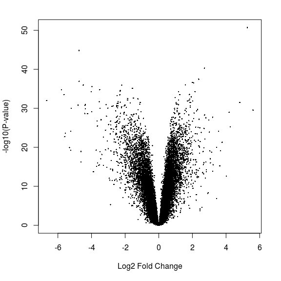

```r
volcanoplot(x2$fit)
```

Здесь довольно много downregulated генов.

```r
oraKEGG(x2)
```

| KEGG ID | Pathway | P.Up | P.Down | Q.Up | Q.Down |
| --- | --- | --- | --- | --- | --- |
| path:hsa05225 | Hepatocellular carcinoma | 0.004027160 | 4.329393e-03 | 0.03979782 | 9.697841e-03 |
| path:hsa05212 | Pancreatic cancer | 0.005306380 | 1.579832e-02 | 0.04802962 | 2.999004e-02 |
| path:hsa05219 | Bladder cancer | 0.007123237 | 9.720381e-02 | 0.05698589 | 1.471193e-01 |
| path:hsa05210 | Colorectal cancer | 0.014253461 | 2.037015e-03 | 0.09969977 | 4.924008e-03 |
| path:hsa05230 | Central carbon metabolism in cancer | 0.023625615 | 1.712944e-02 | 0.14433103 | 3.233423e-02 |
| path:hsa05206 | MicroRNAs in cancer | 0.024093760 | 1.467185e-07 | 0.14456256 | 1.006070e-06 |
| path:hsa05222 | Small cell lung cancer | 0.054528851 | 2.170350e-01 | 0.26173848 | 2.952379e-01 |
| path:hsa05216 | Thyroid cancer | 0.086061950 | 1.518343e-01 | 0.37072840 | 2.180184e-01 |
| path:hsa05223 | Non-small cell lung cancer | 0.140868995 | 9.369838e-05 | 0.50202292 | 2.998348e-04 |
| path:hsa05224 | Breast cancer | 0.141941004 | 4.852895e-02 | 0.50202292 | 7.920098e-02 |

```r
ora2KEGG(x2)
```

|  | ID | Description | pvalue | qvalue |
| --- | --- | --- | --- | --- |
| 1 | hsa05206 | MicroRNAs in cancer | 0.0001039541 | 0.004902257 |
| 2 | hsa05222 | Small cell lung cancer | 0.0044245818 | 0.080251525 |
| 3 | hsa05219 | Bladder cancer | 0.0256890954 | 0.242288732 |
| 4 | hsa05224 | Breast cancer | 0.0709842545 | 0.464926112 |
| 5 | hsa05225 | Hepatocellular carcinoma | 0.1173754041 | 0.615019661 |
| 6 | hsa05210 | Colorectal cancer | 0.1379811924 | 0.648571662 |
| 7 | hsa05226 | Gastric cancer | 0.1402825760 | 0.648571662 |
| 8 | hsa05216 | Thyroid cancer | 0.1950183943 | 0.760483311 |
| 9 | hsa05212 | Pancreatic cancer | 0.2040583791 | 0.763727267 |
| 10 | hsa05213 | Endometrial cancer | 0.2166609988 | 0.770443363 |

Наблюдаем несогласие между двумя разными реализациями ORA. Возможно их рассудит GSEA:

```r
gseaKEGG(x2)
```

|  | ID | Description | pvalue | qvalues |
| --- | --- | --- | --- | --- |
| 1 | hsa05222 | Small cell lung cancer | 0.003868828 | 0.01392038 |
| 2 | hsa05205 | Proteoglycans in cancer | 0.005146565 | 0.01726234 |
| 3 | hsa05231 | Choline metabolism in cancer | 0.011231006 | 0.02726895 |
| 4 | hsa05219 | Bladder cancer | 0.011437004 | 0.02726895 |
| 5 | hsa05225 | Hepatocellular carcinoma | 0.055807211 | 0.09051889 |
| 6 | hsa05206 | MicroRNAs in cancer | 0.056261343 | 0.09051889 |
| 7 | hsa05235 | PD-L1 expression and PD-1 checkpoint pathway in cancer | 0.085651698 | 0.12463250 |
| 8 | hsa05226 | Gastric cancer | 0.122835794 | 0.16098382 |
| 9 | hsa05230 | Central carbon metabolism in cancer | 0.170236337 | 0.19586555 |
| 10 | hsa05202 | Transcriptional misregulation in cancer | 0.196710380 | 0.21250853 |

2 из 3 методов в пользу **hsa05222:Small cell lung cancer**. Хотя для **hsa05225:Hepatocellular carcinoma** у первого метода значимый результат.

### Dataset 3

```r
x3 <- eset2Fit(eset = norm_data$`Dataset #3`)
```

```r
estimateDE(x3)
```

```
downregulated  nonregulated   upregulated
         1697         38777          1624
```

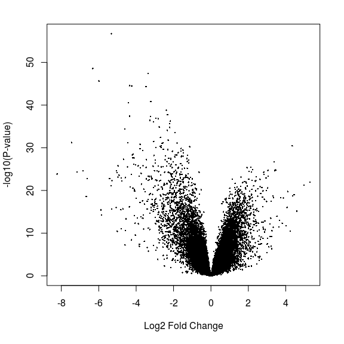

```r
volcanoplot(x3$fit)
```

Снова довольно много downregulated генов.

```r
oraKEGG(x3)
```

| KEGG ID | Pathway | P.Up | P.Down | Q.Up | Q.Down |
| --- | --- | --- | --- | --- | --- |
| path:hsa05206 | MicroRNAs in cancer | 7.519691e-05 | 0.0157411944 | 0.001203151 | 0.0339041109 |
| path:hsa05225 | Hepatocellular carcinoma | 1.692929e-02 | 0.0240343034 | 0.153736266 | 0.0475030937 |
| path:hsa05219 | Bladder cancer | 2.155625e-02 | 0.1667579415 | 0.185715347 | 0.2308353277 |
| path:hsa05215 | Prostate cancer | 3.280352e-02 | 0.0155558078 | 0.234510254 | 0.0337918944 |
| path:hsa05223 | Non-small cell lung cancer | 5.335991e-02 | 0.0376946827 | 0.358578608 | 0.0673777170 |
| path:hsa05205 | Proteoglycans in cancer | 8.868784e-02 | 0.0012593245 | 0.488510094 | 0.0041901233 |
| path:hsa05224 | Breast cancer | 8.594667e-02 | 0.1094895584 | 0.488510094 | 0.1642343376 |
| path:hsa05222 | Small cell lung cancer | 9.493654e-02 | 0.0058451621 | 0.514494808 | 0.0153435505 |
| path:hsa05211 | Renal cell carcinoma | 1.769371e-01 | 0.0001513635 | 0.762190489 | 0.0008709308 |
| path:hsa05210 | Colorectal cancer | 1.877447e-01 | 0.0010865886 | 0.798509266 | 0.0038839764 |

```r
ora2KEGG(x3)
```

|  | ID | Description | pvalue | qvalue |
| --- | --- | --- | --- | --- |
| 1 | hsa05206 | MicroRNAs in cancer | 3.724733e-06 | 0.0002381869 |
| 2 | hsa05222 | Small cell lung cancer | 3.984330e-03 | 0.0727964018 |
| 3 | hsa05219 | Bladder cancer | 1.129844e-02 | 0.1376200766 |
| 4 | hsa05210 | Colorectal cancer | 2.779715e-02 | 0.2746811086 |
| 5 | hsa05224 | Breast cancer | 7.991181e-02 | 0.5524486297 |
| 6 | hsa05216 | Thyroid cancer | 3.143010e-01 | 0.9403469191 |
| 7 | hsa05225 | Hepatocellular carcinoma | 3.249982e-01 | 0.9403469191 |
| 8 | hsa05215 | Prostate cancer | 3.252252e-01 | 0.9403469191 |
| 9 | hsa05212 | Pancreatic cancer | 3.641750e-01 | 0.9403469191 |
| 10 | hsa05226 | Gastric cancer | 4.252238e-01 | 0.9403469191 |

```r
gseaKEGG(x3)
```

|  | ID | Description | pvalue | qvalues |
| --- | --- | --- | --- | --- |
| 1 | hsa05206 | MicroRNAs in cancer | 0.001217039 | 0.006397004 |
| 2 | hsa05219 | Bladder cancer | 0.016316100 | 0.046171328 |
| 3 | hsa05224 | Breast cancer | 0.037472149 | 0.090103315 |
| 4 | hsa05222 | Small cell lung cancer | 0.109033028 | 0.179396850 |
| 5 | hsa05231 | Choline metabolism in cancer | 0.212482608 | 0.268555233 |
| 6 | hsa05211 | Renal cell carcinoma | 0.213442689 | 0.268555233 |
| 7 | hsa05210 | Colorectal cancer | 0.233572282 | 0.278991186 |
| 8 | hsa05225 | Hepatocellular carcinoma | 0.238153346 | 0.278991186 |
| 9 | hsa05205 | Proteoglycans in cancer | 0.324825031 | 0.330736751 |
| 10 | hsa05230 | Central carbon metabolism in cancer | 0.346576163 | 0.346366602 |

Здесь видим большие разногласия между методами. Но стоит заметить, что предпочитаемый GSEA Bladder cancer на высоких позициях и у других методов, так что сойдемся на нём. Ответ - **hsa05219:Bladder cancer**.

### Dataset 4

```r
x4 <- eset2Fit(eset = norm_data$`Dataset #4`)
```

```r
estimateDE(x4)
```

```
downregulated  nonregulated   upregulated
         1446         39192          1460
```

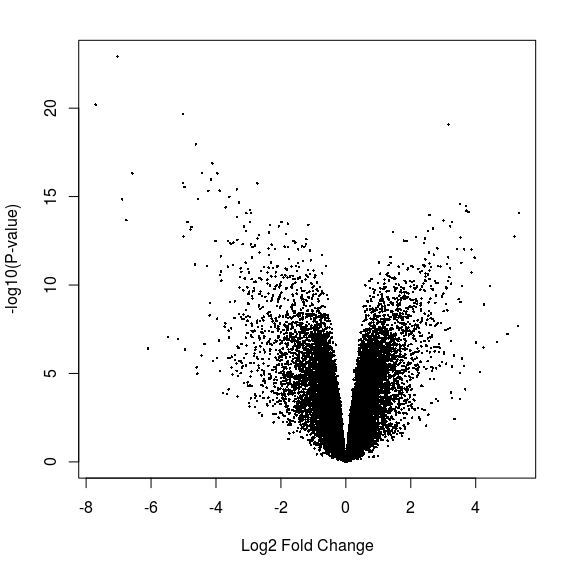

```r
volcanoplot(x4$fit)
```

Снова множество downregulated генов.

```r
oraKEGG(x4)
```

| KEGG ID | Pathway | P.Up | P.Down | Q.Up | Q.Down |
| --- | --- | --- | --- | --- | --- |
| path:hsa05235 | PD-L1 expression and PD-1 checkpoint pathway in cancer | 7.355437e-08 | 0.9889824 | 9.952912e-07 | 1.0000000 |
| path:hsa05206 | MicroRNAs in cancer | 2.249282e-05 | 0.3247669 | 1.349569e-04 | 0.7265275 |
| path:hsa05212 | Pancreatic cancer | 3.048759e-05 | 0.3936110 | 1.626005e-04 | 0.7919143 |
| path:hsa05211 | Renal cell carcinoma | 2.824183e-04 | 0.8388839 | 1.265234e-03 | 1.0000000 |
| path:hsa05200 | Pathways in cancer | 4.539774e-04 | 0.6365101 | 1.955595e-03 | 0.9810431 |
| path:hsa05210 | Colorectal cancer | 4.631673e-04 | 0.4989449 | 1.969927e-03 | 0.8641519 |
| path:hsa05202 | Transcriptional misregulation in cancer | 5.032422e-04 | 0.6159773 | 2.113617e-03 | 0.9765779 |
| path:hsa05223 | Non-small cell lung cancer | 9.495266e-04 | 0.2628842 | 3.843867e-03 | 0.6542896 |
| path:hsa05219 | Bladder cancer | 4.777378e-03 | 0.7010787 | 1.672082e-02 | 1.0000000 |
| path:hsa05222 | Small cell lung cancer | 4.760819e-03 | 0.4519093 | 1.672082e-02 | 0.8299095 |

```r
ora2KEGG(x4)
```

|  | ID | Description | pvalue | qvalue |
| --- | --- | --- | --- | --- |
| 1 | hsa05202 | Transcriptional misregulation in cancer | 0.0001082377 | 0.0007093338 |
| 2 | hsa05219 | Bladder cancer | 0.0001303028 | 0.0008272515 |
| 3 | hsa05212 | Pancreatic cancer | 0.0033843126 | 0.0143239546 |
| 4 | hsa05206 | MicroRNAs in cancer | 0.0144454317 | 0.0473676672 |
| 5 | hsa05205 | Proteoglycans in cancer | 0.0173386460 | 0.0525743705 |
| 6 | hsa05223 | Non-small cell lung cancer | 0.0217989363 | 0.0641829857 |
| 7 | hsa05230 | Central carbon metabolism in cancer | 0.0239989114 | 0.0696509760 |
| 8 | hsa05210 | Colorectal cancer | 0.0468719545 | 0.1175605877 |
| 9 | hsa05211 | Renal cell carcinoma | 0.0607404075 | 0.1469034918 |
| 10 | hsa05222 | Small cell lung cancer | 0.0748123952 | 0.1788085731 |

```r
gseaKEGG(x4)
```

|  | ID | Description | pvalue | qvalues |
| --- | --- | --- | --- | --- |
| 1 | hsa05206 | MicroRNAs in cancer | 0.002534113 | 0.005397739 |
| 2 | hsa05202 | Transcriptional misregulation in cancer | 0.007608272 | 0.013504878 |
| 3 | hsa05211 | Renal cell carcinoma | 0.011705033 | 0.019442450 |
| 4 | hsa05205 | Proteoglycans in cancer | 0.043401414 | 0.059529850 |
| 5 | hsa05230 | Central carbon metabolism in cancer | 0.057891649 | 0.075952430 |
| 6 | hsa05222 | Small cell lung cancer | 0.068471338 | 0.087921389 |
| 7 | hsa05219 | Bladder cancer | 0.074394464 | 0.093536899 |
| 8 | hsa05235 | PD-L1 expression and PD-1 checkpoint pathway in cancer | 0.083547812 | 0.100843675 |
| 9 | hsa05231 | Choline metabolism in cancer | 0.120540214 | 0.136400768 |
| 10 | hsa05226 | Gastric cancer | 0.163833709 | 0.168537069 |

### Dataset 5

```r
x5 <- eset2Fit(eset = norm_data$`Dataset #5`)
```

```r
estimateDE(x5)
```

```
downregulated  nonregulated   upregulated
            0         19854             0
```

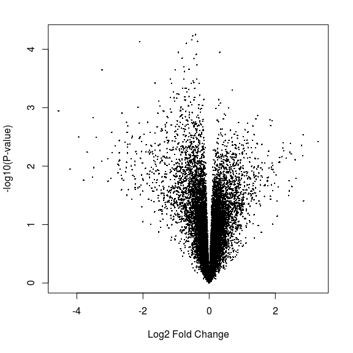

```r
volcanoplot(x5$fit)
```

В этом датасете limma вообще не определила дифференциально экспрессирующихся генов! Забегая вперед, скажу, что это видимо особенность датасетов, полученных на hgu133a: в других датасетах с этого же чипа (8 и 9) limma также не определила DE-генов. Придется использовать исключительно GSEA метод анализа.

```r
gseaKEGG(x5)
```

|  | ID | Description | pvalue | qvalues |
| --- | --- | --- | --- | --- |
| 1 | hsa05206 | MicroRNAs in cancer | 0.0006315125 | 0.001619743 |
| 2 | hsa05235 | PD-L1 expression and PD-1 checkpoint pathway in cancer | 0.0024403471 | 0.005167442 |
| 3 | hsa05202 | Transcriptional misregulation in cancer | 0.0061748456 | 0.011358302 |
| 4 | hsa05205 | Proteoglycans in cancer | 0.0133155792 | 0.021085540 |
| 5 | hsa05222 | Small cell lung cancer | 0.0232945092 | 0.034210103 |
| 6 | hsa05211 | Renal cell carcinoma | 0.0649081976 | 0.085653075 |
| 7 | hsa05219 | Bladder cancer | 0.0749756573 | 0.096151139 |
| 8 | hsa05212 | Pancreatic cancer | 0.0865743207 | 0.108728548 |
| 9 | hsa05216 | Thyroid cancer | 0.1457528958 | 0.162836622 |
| 10 | hsa05230 | Central carbon metabolism in cancer | 0.1673131627 | 0.180287618 |

Здесь **hsa05222:Small cell lung cancer**.

### Dataset 6

```r
x6 <- eset2Fit(eset = norm_data$`Dataset #6`)
```

```r
estimateDE(x6)
```

```
downregulated  nonregulated   upregulated
          398         40153          1547
```

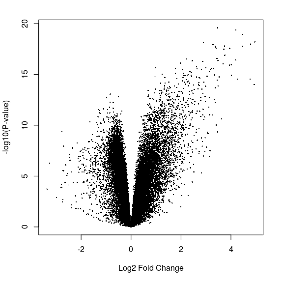

```r
volcanoplot(x6$fit)
```

Очень много upregulated генов!

```r
oraKEGG(x6)
```

| KEGG ID | Pathway | P.Up | P.Down | Q.Up | Q.Down |
| --- | --- | --- | --- | --- | --- |
| path:hsa05200 | Pathways in cancer | 3.359906e-14 | 0.746788392 | 2.822321e-12 | 1.00000000 |
| path:hsa05205 | Proteoglycans in cancer | 6.914432e-14 | 0.743846832 | 4.646498e-12 | 1.00000000 |
| path:hsa05206 | MicroRNAs in cancer | 3.907839e-13 | 0.681557293 | 2.188390e-11 | 1.00000000 |
| path:hsa05212 | Pancreatic cancer | 4.291127e-08 | 0.665215359 | 5.524613e-07 | 1.00000000 |
| path:hsa05202 | Transcriptional misregulation in cancer | 1.354810e-07 | 0.911403181 | 1.264489e-06 | 1.00000000 |
| path:hsa05210 | Colorectal cancer | 1.582845e-07 | 0.303121688 | 1.399568e-06 | 0.77158248 |
| path:hsa05211 | Renal cell carcinoma | 2.696296e-06 | 0.093822816 | 1.848889e-05 | 0.35420749 |
| path:hsa05222 | Small cell lung cancer | 4.072425e-06 | 0.868199194 | 2.631413e-05 | 1.00000000 |
| path:hsa05225 | Hepatocellular carcinoma | 7.992548e-06 | 0.005936235 | 4.882720e-05 | 0.06648583 |
| path:hsa05215 | Prostate cancer | 1.148195e-05 | 0.342023413 | 6.538871e-05 | 0.81977210 |

```r
ora2KEGG(x6)
```

|  | ID | Description | pvalue | qvalue |
| --- | --- | --- | --- | --- |
| 1 | hsa05205 | Proteoglycans in cancer | 4.321365e-07 | 6.683244e-06 |
| 2 | hsa05222 | Small cell lung cancer | 2.460974e-05 | 2.473927e-04 |
| 3 | hsa05202 | Transcriptional misregulation in cancer | 8.013974e-05 | 7.005350e-04 |
| 4 | hsa05206 | MicroRNAs in cancer | 2.111657e-04 | 1.632901e-03 |
| 5 | hsa05215 | Prostate cancer | 4.676701e-02 | 1.482715e-01 |
| 6 | hsa05230 | Central carbon metabolism in cancer | 5.124188e-02 | 1.560957e-01 |
| 7 | hsa05217 | Basal cell carcinoma | 6.628329e-02 | 1.903776e-01 |
| 8 | hsa05219 | Bladder cancer | 7.289134e-02 | 2.064084e-01 |
| 9 | hsa05210 | Colorectal cancer | 1.608235e-01 | 3.775098e-01 |
| 10 | hsa05226 | Gastric cancer | 2.435538e-01 | 5.154436e-01 |

```r
gseaKEGG(x6)
```

|  | ID | Description | pvalue | qvalues |
| --- | --- | --- | --- | --- |
| 1 | hsa05205 | Proteoglycans in cancer | 0.0001287167 | 0.0007274148 |
| 2 | hsa05206 | MicroRNAs in cancer | 0.0001325205 | 0.0007274148 |
| 3 | hsa05222 | Small cell lung cancer | 0.0001446969 | 0.0007274148 |
| 4 | hsa05202 | Transcriptional misregulation in cancer | 0.0002615063 | 0.0010318992 |
| 5 | hsa05215 | Prostate cancer | 0.0094596531 | 0.0170839969 |
| 6 | hsa05230 | Central carbon metabolism in cancer | 0.0322242206 | 0.0482604930 |
| 7 | hsa05219 | Bladder cancer | 0.0633215774 | 0.0822120144 |
| 8 | hsa05211 | Renal cell carcinoma | 0.0645836448 | 0.0831957147 |
| 9 | hsa05212 | Pancreatic cancer | 0.1331948977 | 0.1460470369 |
| 10 | hsa05217 | Basal cell carcinoma | 0.2043158861 | 0.2026325757 |

Вновь разногласия, но у первого метода очень значимый результат для **hsa05212:Pancreatic cancer**. Остановимся на нем.

### Dataset 7

```r
x7 <- eset2Fit(eset = norm_data$`Dataset #7`)
```

```r
estimateDE(x7)
```

```
downregulated  nonregulated   upregulated
          288         40822           988
```

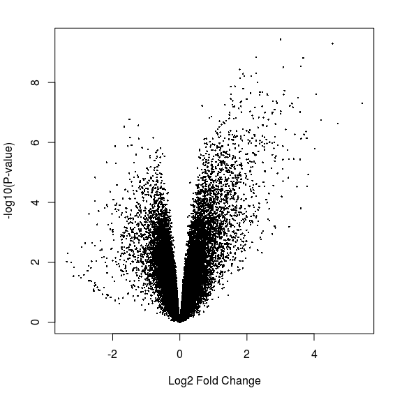

```r
volcanoplot(x7$fit)
```

```r
oraKEGG(x7)
```

| KEGG ID | Pathway | P.Up | P.Down | Q.Up | Q.Down |
| --- | --- | --- | --- | --- | --- |
| path:hsa05206 | MicroRNAs in cancer | 6.987607e-07 | 0.30399341 | 1.806028e-05 | 0.8511815 |
| path:hsa05205 | Proteoglycans in cancer | 9.504180e-07 | 0.70605292 | 2.281003e-05 | 1.0000000 |
| path:hsa05200 | Pathways in cancer | 1.484412e-05 | 0.18912121 | 2.493811e-04 | 0.7208325 |
| path:hsa05202 | Transcriptional misregulation in cancer | 5.310802e-04 | 0.08501683 | 4.822782e-03 | 0.5011518 |
| path:hsa05222 | Small cell lung cancer | 1.362001e-03 | 0.86728184 | 1.064261e-02 | 1.0000000 |
| path:hsa05219 | Bladder cancer | 1.567339e-03 | 0.64591942 | 1.170280e-02 | 1.0000000 |
| path:hsa05212 | Pancreatic cancer | 2.568760e-03 | 0.86581073 | 1.813446e-02 | 1.0000000 |
| path:hsa05210 | Colorectal cancer | 3.388883e-03 | 0.13888770 | 2.316282e-02 | 0.6222169 |
| path:hsa05230 | Central carbon metabolism in cancer | 4.974178e-03 | 0.16337148 | 3.277106e-02 | 0.6948458 |
| path:hsa05225 | Hepatocellular carcinoma | 2.074954e-02 | 0.19369870 | 9.296480e-02 | 0.7208325 |

```r
ora2KEGG(x7)
```

|  | ID | Description | pvalue | qvalue |
| --- | --- | --- | --- | --- |
| 1 | hsa05202 | Transcriptional misregulation in cancer | 0.0002199615 | 0.01325196 |
| 2 | hsa05206 | MicroRNAs in cancer | 0.0009034209 | 0.04051129 |
| 3 | hsa05205 | Proteoglycans in cancer | 0.0013016714 | 0.04864140 |
| 4 | hsa05222 | Small cell lung cancer | 0.0082303641 | 0.12302228 |
| 5 | hsa05230 | Central carbon metabolism in cancer | 0.0808097208 | 0.43139024 |
| 6 | hsa05210 | Colorectal cancer | 0.0884216724 | 0.44471513 |
| 7 | hsa05219 | Bladder cancer | 0.1120298537 | 0.49251515 |
| 8 | hsa05211 | Renal cell carcinoma | 0.1921137533 | 0.68371311 |
| 9 | hsa05212 | Pancreatic cancer | 0.2585606398 | 0.75288334 |
| 10 | hsa05217 | Basal cell carcinoma | 0.2860711289 | 0.78356070 |

```r
gseaKEGG(x7)
```

|  | ID | Description | pvalue | qvalues |
| --- | --- | --- | --- | --- |
| 1 | hsa05205 | Proteoglycans in cancer | 0.0002425124 | 0.002552281 |
| 2 | hsa05222 | Small cell lung cancer | 0.0002706726 | 0.002552281 |
| 3 | hsa05206 | MicroRNAs in cancer | 0.0005000000 | 0.003094099 |
| 4 | hsa05202 | Transcriptional misregulation in cancer | 0.0042100050 | 0.012831751 |
| 5 | hsa05219 | Bladder cancer | 0.0349404944 | 0.067954445 |
| 6 | hsa05226 | Gastric cancer | 0.0514836419 | 0.091945113 |
| 7 | hsa05215 | Prostate cancer | 0.0660225443 | 0.107921673 |
| 8 | hsa05230 | Central carbon metabolism in cancer | 0.0766042590 | 0.120333816 |
| 9 | hsa05217 | Basal cell carcinoma | 0.1038472664 | 0.150402163 |
| 10 | hsa05211 | Renal cell carcinoma | 0.1153955606 | 0.161010922 |

Наконец-то единогласие! **hsa05222:Small cell lung cancer**.

### Dataset 8

```r
x8 <- eset2Fit(eset = norm_data$`Dataset #8`)
```

```r
estimateDE(x8)
```

```
downregulated  nonregulated   upregulated
            0         19854             0
```

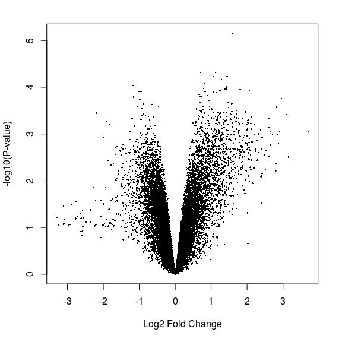

```r
volcanoplot(x8$fit)
```

Без DE генов! Используем исключительно GSEA:

```r
gseaKEGG(x8)
```

|  | ID | Description | pvalue | qvalues |
| --- | --- | --- | --- | --- |
| 1 | hsa05231 | Choline metabolism in cancer | 0.03745086 | 0.1583341 |
| 2 | hsa05206 | MicroRNAs in cancer | 0.04340671 | 0.1776883 |
| 3 | hsa05222 | Small cell lung cancer | 0.05149631 | 0.2012216 |
| 4 | hsa05215 | Prostate cancer | 0.13357994 | 0.3395089 |
| 5 | hsa05213 | Endometrial cancer | 0.13427925 | 0.3395089 |
| 6 | hsa05212 | Pancreatic cancer | 0.17043334 | 0.3724904 |

Выбора нет, кроме **hsa05222:Small cell lung cancer**.

### Dataset 9

```r
x9 <- eset2Fit(eset = norm_data$`Dataset #9`)
```

```r
estimateDE(x9)
```

```
downregulated  nonregulated   upregulated
            0         19854             0
```

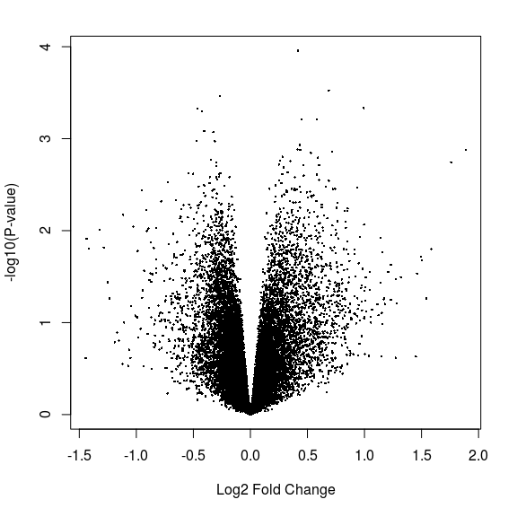

```r
volcanoplot(x9$fit)
```

Ещё один датасет без DE генов, и к тому же с самыми слабыми изменениями в экспрессии.

```r
gseaKEGG(x9)
```

|  | ID | Description | pvalue | qvalues |
| --- | --- | --- | --- | --- |
| 1 | hsa05206 | MicroRNAs in cancer | 0.0004095004 | 0.01774502 |
| 2 | hsa05205 | Proteoglycans in cancer | 0.0010076582 | 0.03742730 |
| 3 | hsa05219 | Bladder cancer | 0.0012389015 | 0.04026430 |
| 4 | hsa05226 | Gastric cancer | 0.0170662332 | 0.14313615 |
| 5 | hsa05213 | Endometrial cancer | 0.0834879406 | 0.28241600 |
| 6 | hsa05231 | Choline metabolism in cancer | 0.0836385836 | 0.28241600 |
| 7 | hsa05224 | Breast cancer | 0.1302211302 | 0.34904633 |
| 8 | hsa05210 | Colorectal cancer | 0.1432382516 | 0.37157354 |
| 9 | hsa05216 | Thyroid cancer | 0.1733937397 | 0.38864114 |

Здесь только **hsa05219:Bladder cancer**.

### Dataset 10

```r
x10 <- eset2Fit(eset = norm_data$`Dataset #10`)
```

```r
estimateDE(x10)
```

```
downregulated  nonregulated   upregulated
          455         41125           518
```

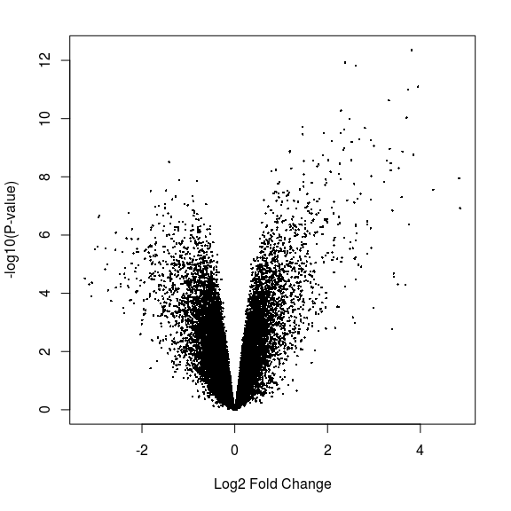

```r
volcanoplot(x10$fit)
```

Теперь датасет с DE генами!

```r
oraKEGG(x10)
```

| KEGG ID | Pathway | P.Up | P.Down | Q.Up | Q.Down |
| --- | --- | --- | --- | --- | --- |
| path:hsa05205 | Proteoglycans in cancer | 7.622867e-08 | 0.8546388 | 1.600802e-06 | 1 |
| path:hsa05206 | MicroRNAs in cancer | 1.322903e-05 | 0.3606380 | 1.111239e-04 | 1 |
| path:hsa05200 | Pathways in cancer | 3.361580e-05 | 0.8300995 | 2.509979e-04 | 1 |
| path:hsa05202 | Transcriptional misregulation in cancer | 1.052060e-04 | 0.4588526 | 7.069843e-04 | 1 |
| path:hsa05222 | Small cell lung cancer | 2.191230e-04 | 0.9068460 | 1.314738e-03 | 1 |
| path:hsa05212 | Pancreatic cancer | 3.141588e-04 | 0.7692646 | 1.730449e-03 | 1 |
| path:hsa05223 | Non-small cell lung cancer | 1.297925e-03 | 0.6280986 | 5.893283e-03 | 1 |
| path:hsa05225 | Hepatocellular carcinoma | 2.591911e-03 | 0.4222895 | 1.104682e-02 | 1 |
| path:hsa05219 | Bladder cancer | 3.079994e-03 | 0.8569760 | 1.282482e-02 | 1 |
| path:hsa05213 | Endometrial cancer | 7.258091e-03 | 0.4867934 | 2.709687e-02 | 1 |

```r
ora2KEGG(x10)
```

|  | ID | Description | pvalue | qvalue |
| --- | --- | --- | --- | --- |
| 1 | hsa05222 | Small cell lung cancer | 0.0000247949 | 0.0007351471 |
| 2 | hsa05205 | Proteoglycans in cancer | 0.0005882083 | 0.0074742252 |
| 3 | hsa05212 | Pancreatic cancer | 0.0007785024 | 0.0092327654 |
| 4 | hsa05206 | MicroRNAs in cancer | 0.0032166252 | 0.0240957719 |
| 5 | hsa05210 | Colorectal cancer | 0.0066351952 | 0.0355848664 |
| 6 | hsa05223 | Non-small cell lung cancer | 0.0073226959 | 0.0371634504 |
| 7 | hsa05226 | Gastric cancer | 0.0130091491 | 0.0558486086 |
| 8 | hsa05202 | Transcriptional misregulation in cancer | 0.0134995009 | 0.0558486086 |
| 9 | hsa05216 | Thyroid cancer | 0.0152857358 | 0.0618011807 |
| 10 | hsa05215 | Prostate cancer | 0.0412278709 | 0.1527962760 |

```r
gseaKEGG(x10)
```

|  | ID | Description | pvalue | qvalues |
| --- | --- | --- | --- | --- |
| 1 | hsa05222 | Small cell lung cancer | 0.0003936233 | 0.002550783 |
| 2 | hsa05202 | Transcriptional misregulation in cancer | 0.0007716049 | 0.004109866 |
| 3 | hsa05219 | Bladder cancer | 0.0013563263 | 0.006287975 |
| 4 | hsa05205 | Proteoglycans in cancer | 0.0072040498 | 0.022982961 |
| 5 | hsa05223 | Non-small cell lung cancer | 0.0099086847 | 0.027036162 |
| 6 | hsa05206 | MicroRNAs in cancer | 0.0110744123 | 0.029442095 |
| 7 | hsa05215 | Prostate cancer | 0.0473868955 | 0.091595719 |
| 8 | hsa05235 | PD-L1 expression and PD-1 checkpoint pathway in cancer | 0.0518562169 | 0.096876953 |
| 9 | hsa05230 | Central carbon metabolism in cancer | 0.0571150097 | 0.105748655 |
| 10 | hsa05212 | Pancreatic cancer | 0.0791520809 | 0.131309136 |

Однозначно **hsa05222:Small cell lung cancer**!

### Dataset 11

```r
x11 <- eset2Fit(eset = norm_data$`Dataset #11`)
```

```r
estimateDE(x11)
```

```
downregulated  nonregulated   upregulated
          610         41061           427
```

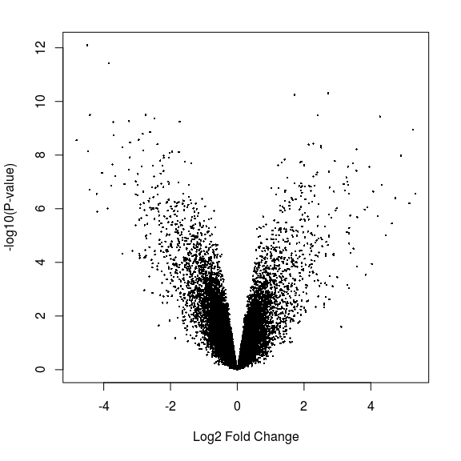

```r
volcanoplot(x11$fit)
```

```r
oraKEGG(x11)
```

| KEGG ID | Pathway | P.Up | P.Down | Q.Up | Q.Down |
| --- | --- | --- | --- | --- | --- |
| path:hsa05205 | Proteoglycans in cancer | 3.714251e-05 | 0.007575910 | 0.004680122 | 0.10182023 |
| path:hsa05202 | Transcriptional misregulation in cancer | 1.022707e-04 | 0.271724467 | 0.005784043 | 0.55395272 |
| path:hsa05222 | Small cell lung cancer | 1.032865e-04 | 0.181010428 | 0.005784043 | 0.43755039 |
| path:hsa05206 | MicroRNAs in cancer | 7.738341e-04 | 0.035501301 | 0.028889806 | 0.18351442 |
| path:hsa05212 | Pancreatic cancer | 2.948252e-03 | 0.205857470 | 0.058271337 | 0.46561491 |
| path:hsa05200 | Pathways in cancer | 5.920395e-03 | 0.002983564 | 0.099462638 | 0.06896305 |
| path:hsa05219 | Bladder cancer | 1.904791e-02 | 0.823360820 | 0.194856685 | 1.00000000 |
| path:hsa05225 | Hepatocellular carcinoma | 1.841165e-02 | 0.208144907 | 0.194856685 | 0.46624459 |
| path:hsa05223 | Non-small cell lung cancer | 2.488660e-02 | 0.137138862 | 0.225997250 | 0.38398881 |
| path:hsa05215 | Prostate cancer | 3.530753e-02 | 0.047670802 | 0.277849647 | 0.21645121 |

```r
ora2KEGG(x11)
```

|  | ID | Description | pvalue | qvalue |
| --- | --- | --- | --- | --- |
| 1 | hsa05222 | Small cell lung cancer | 9.867176e-05 | 0.01807251 |
| 2 | hsa05212 | Pancreatic cancer | 4.413410e-03 | 0.13472515 |
| 3 | hsa05206 | MicroRNAs in cancer | 5.525219e-03 | 0.13504515 |
| 4 | hsa05205 | Proteoglycans in cancer | 6.635839e-03 | 0.13504515 |
| 5 | hsa05202 | Transcriptional misregulation in cancer | 7.823178e-03 | 0.14328768 |
| 6 | hsa05223 | Non-small cell lung cancer | 1.090250e-02 | 0.18153443 |
| 7 | hsa05226 | Gastric cancer | 2.764459e-02 | 0.26649083 |
| 8 | hsa05216 | Thyroid cancer | 3.907528e-02 | 0.28844949 |
| 9 | hsa05225 | Hepatocellular carcinoma | 4.252462e-02 | 0.28844949 |
| 10 | hsa05215 | Prostate cancer | 4.784971e-02 | 0.28844949 |

```r
gseaKEGG(x11)
```

|  | ID | Description | pvalue | qvalues |
| --- | --- | --- | --- | --- |
| 1 | hsa05205 | Proteoglycans in cancer | 0.02584814 | 0.1354876 |
| 2 | hsa05210 | Colorectal cancer | 0.03815499 | 0.1781783 |
| 3 | hsa05231 | Choline metabolism in cancer | 0.11114848 | 0.3207597 |
| 4 | hsa05222 | Small cell lung cancer | 0.14423314 | 0.3680638 |
| 5 | hsa05206 | MicroRNAs in cancer | 0.15384615 | 0.3692913 |
| 6 | hsa05217 | Basal cell carcinoma | 0.16896732 | 0.3889867 |

ORA-методы сходятся нa **hsa05222:Small cell lung cancer**. У GSEA слишком слабый результат, чтобы его учитывать.

### Dataset 12

```r
x12 <- eset2Fit(eset = norm_data$`Dataset #12`)
```

```r
estimateDE(x12)
```

```
downregulated  nonregulated   upregulated
         2342         37779          1977
```

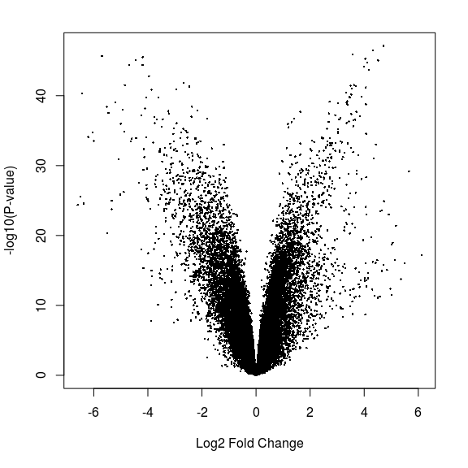

```r
volcanoplot(x12$fit)
```

Больше всего DE генов!

```r
oraKEGG(x12)
```

| KEGG ID | Pathway | P.Up | P.Down | Q.Up | Q.Down |
| --- | --- | --- | --- | --- | --- |
| path:hsa05230 | Central carbon metabolism in cancer | 6.934962e-05 | 7.438903e-01 | 0.001370675 | 0.9023362026 |
| path:hsa05206 | MicroRNAs in cancer | 2.779836e-04 | 3.170688e-03 | 0.004670124 | 0.0104446200 |
| path:hsa05219 | Bladder cancer | 3.012357e-03 | 6.227763e-01 | 0.028115333 | 0.8017350294 |
| path:hsa05225 | Hepatocellular carcinoma | 3.142936e-03 | 1.349898e-01 | 0.028235335 | 0.2399818197 |
| path:hsa05224 | Breast cancer | 1.723147e-02 | 2.676578e-01 | 0.115795482 | 0.4125367808 |
| path:hsa05226 | Gastric cancer | 2.093316e-02 | 5.591775e-01 | 0.135260433 | 0.7367986297 |
| path:hsa05200 | Pathways in cancer | 5.375111e-02 | 3.388006e-05 | 0.258005349 | 0.0001778703 |
| path:hsa05212 | Pancreatic cancer | 6.439165e-02 | 3.552621e-02 | 0.292372916 | 0.0792024554 |
| path:hsa05222 | Small cell lung cancer | 8.133797e-02 | 1.235127e-01 | 0.338057032 | 0.2230092754 |
| path:hsa05211 | Renal cell carcinoma | 1.089199e-01 | 1.966181e-02 | 0.393517090 | 0.0475278324 |

```r
ora2KEGG(x12)
```

|  | ID | Description | pvalue | qvalue |
| --- | --- | --- | --- | --- |
| 1 | hsa05206 | MicroRNAs in cancer | 2.575196e-05 | 0.001387895 |
| 2 | hsa05222 | Small cell lung cancer | 4.455700e-02 | 0.452886683 |
| 3 | hsa05219 | Bladder cancer | 1.780331e-01 | 0.872276763 |
| 4 | hsa05211 | Renal cell carcinoma | 2.980254e-01 | 0.948796026 |
| 5 | hsa05202 | Transcriptional misregulation in cancer | 3.189690e-01 | 0.948796026 |
| 6 | hsa05205 | Proteoglycans in cancer | 3.681387e-01 | 0.948796026 |
| 7 | hsa05215 | Prostate cancer | 4.178042e-01 | 0.948796026 |
| 8 | hsa05217 | Basal cell carcinoma | 4.919006e-01 | 0.948796026 |
| 9 | hsa05225 | Hepatocellular carcinoma | 5.102160e-01 | 0.948796026 |
| 10 | hsa05210 | Colorectal cancer | 5.430398e-01 | 0.948796026 |

```r
gseaKEGG(x12)
```

|  | ID | Description | pvalue | qvalues |
| --- | --- | --- | --- | --- |
| 1 | hsa05235 | PD-L1 expression and PD-1 checkpoint pathway in cancer | 0.01132721 | 0.02434810 |
| 2 | hsa05206 | MicroRNAs in cancer | 0.03187251 | 0.05500993 |
| 3 | hsa05202 | Transcriptional misregulation in cancer | 0.06648375 | 0.09497936 |
| 4 | hsa05231 | Choline metabolism in cancer | 0.09584394 | 0.12490939 |
| 5 | hsa05230 | Central carbon metabolism in cancer | 0.11952266 | 0.14492421 |
| 6 | hsa05205 | Proteoglycans in cancer | 0.19090327 | 0.19662928 |
| 7 | hsa05219 | Bladder cancer | 0.23420852 | 0.22776357 |
| 8 | hsa05215 | Prostate cancer | 0.30798335 | 0.27831663 |
| 9 | hsa05223 | Non-small cell lung cancer | 0.35750963 | 0.30713596 |

Последние 2 метода показали слабый результат, а первый предлагает **hsa05219:Bladder cancer**.

### Dataset 13

```r
x13 <- eset2Fit(eset = norm_data$`Dataset #13`)
```

```r
estimateDE(x13)
```

```
downregulated  nonregulated   upregulated
         2119         38878          1101
```

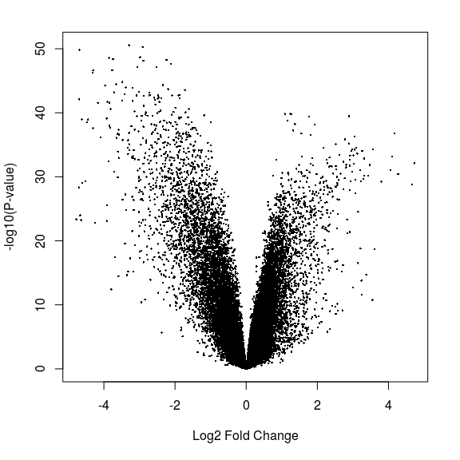

```r
volcanoplot(x13$fit)
```

```r
oraKEGG(x13)
```

| KEGG ID | Pathway | P.Up | P.Down | Q.Up | Q.Down |
| --- | --- | --- | --- | --- | --- |
| path:hsa05206 | MicroRNAs in cancer | 0.0007407135 | 2.145414e-05 | 0.009955189 | 1.001193e-04 |
| path:hsa05230 | Central carbon metabolism in cancer | 0.0039711010 | 5.577352e-01 | 0.045074519 | 7.098447e-01 |
| path:hsa05225 | Hepatocellular carcinoma | 0.0064655721 | 4.049962e-03 | 0.062069493 | 9.789837e-03 |
| path:hsa05224 | Breast cancer | 0.0193682112 | 2.086396e-02 | 0.135577479 | 4.197779e-02 |
| path:hsa05211 | Renal cell carcinoma | 0.0224689550 | 4.795000e-04 | 0.154072834 | 1.438500e-03 |
| path:hsa05226 | Gastric cancer | 0.0511148078 | 7.329626e-02 | 0.291094499 | 1.276038e-01 |
| path:hsa05215 | Prostate cancer | 0.1051657173 | 1.652837e-04 | 0.484050425 | 5.609627e-04 |
| path:hsa05205 | Proteoglycans in cancer | 0.1327927584 | 1.693495e-09 | 0.594153898 | 2.386152e-08 |
| path:hsa05212 | Pancreatic cancer | 0.2422111963 | 5.883651e-04 | 0.847739187 | 1.661266e-03 |
| path:hsa05223 | Non-small cell lung cancer | 0.2910750833 | 5.625885e-04 | 0.941714087 | 1.601947e-03 |

```r
ora2KEGG(x13)
```

|  | ID | Description | pvalue | qvalue |
| --- | --- | --- | --- | --- |
| 1 | hsa05206 | MicroRNAs in cancer | 1.502799e-06 | 9.254081e-05 |
| 2 | hsa05202 | Transcriptional misregulation in cancer | 1.317029e-01 | 8.536977e-01 |
| 3 | hsa05230 | Central carbon metabolism in cancer | 2.972960e-01 | 9.693381e-01 |
| 4 | hsa05222 | Small cell lung cancer | 3.816799e-01 | 9.693381e-01 |
| 5 | hsa05219 | Bladder cancer | 3.851377e-01 | 9.693381e-01 |
| 6 | hsa05215 | Prostate cancer | 4.308215e-01 | 9.693381e-01 |
| 7 | hsa05210 | Colorectal cancer | 4.921204e-01 | 9.693381e-01 |
| 8 | hsa05205 | Proteoglycans in cancer | 4.979365e-01 | 9.693381e-01 |
| 9 | hsa05211 | Renal cell carcinoma | 5.077025e-01 | 9.693381e-01 |
| 10 | hsa05231 | Choline metabolism in cancer | 7.652526e-01 | 9.693381e-01 |

```r
gseaKEGG(x13)
```

|  | ID | Description | pvalue | qvalues |
| --- | --- | --- | --- | --- |
| 1 | hsa05205 | Proteoglycans in cancer | 0.01151341 | 0.02004358 |
| 2 | hsa05235 | PD-L1 expression and PD-1 checkpoint pathway in cancer | 0.01597444 | 0.02582334 |
| 3 | hsa05202 | Transcriptional misregulation in cancer | 0.01716937 | 0.02679793 |
| 4 | hsa05206 | MicroRNAs in cancer | 0.06497797 | 0.08189058 |
| 5 | hsa05231 | Choline metabolism in cancer | 0.09001171 | 0.10528271 |
| 6 | hsa05219 | Bladder cancer | 0.32182878 | 0.27101371 |
| 7 | hsa05217 | Basal cell carcinoma | 0.36407767 | 0.29352370 |

Последние два метода выдают отвратительный результат, так что тут пользоваться только результатом первого - **hsa05225:Hepatocellular carcinoma**.

### Итог

1. hsa05224_Breast_cancer
2. hsa05222_Small_cell_lung_cancer или hsa05225_Hepatocellular_carcinoma
3. hsa05219_Bladder_cancer
4. hsa05212_Pancreatic_cancer
5. hsa05222_Small_cell_lung_cancer
6. hsa05212_Pancreatic_cancer
7. hsa05222_Small_cell_lung_cancer
8. hsa05222_Small_cell_lung_cancer
9. hsa05219_Bladder_cancer
10. hsa05222_Small_cell_lung_cancer
11. hsa05222_Small_cell_lung_cancer
12. hsa05219_Bladder_cancer
13. hsa05225_Hepatocellular_carcinoma